# Analysis

```r
# Loading libraries and data
library(readxl)
library(janitor)
library(MASS)
library(tidyverse)
library(broom)
library(purrr)
library(cowplot)
library(car)
library(AER)
library(knitr)

GARDEN_FILE_PATH <- "data/raw/GARDENS_spreadsheet.xlsx"
garden_data <- read_excel(GARDEN_FILE_PATH, sheet='Everything_statistics') |>
  clean_names() # clean column names

coniferous_data <- read_excel(GARDEN_FILE_PATH, sheet='Tree_per_garden') |>
  clean_names() |>
  filter(coniferous_not == "con") |>
  group_by(id) |>
  summarise(coniferous_canopy = sum(crown_area))

garden_data <- left_join(garden_data, coniferous_data, by = c("house" = "id")) |>
  mutate(coniferous_canopy = replace_na(coniferous_canopy, 0))

native_tree_canopy_data <- read_excel(GARDEN_FILE_PATH, sheet='Tree_per_garden') |>
  clean_names() |>
  group_by(id) |>
  summarise(
    total_canopy = sum(crown_area, na.rm = TRUE),
    native_canopy = sum(crown_area[native_or_non_native == "Native"], na.rm = TRUE)
  ) |>
  mutate(
    native_canopy_prop = native_canopy/total_canopy
  )

garden_data <- left_join(garden_data, native_tree_canopy_data, by = c("house" = "id")) |>
  mutate(native_canopy = replace_na(native_canopy, 0),
         total_canopy = replace_na(total_canopy, 0),
         native_canopy_prop = replace_na(native_canopy_prop, 0))


BIRD_FILE_PATH <- "data/raw/BIRDS_spreadsheet2.xlsx"
bird_data <- read_excel(BIRD_FILE_PATH, sheet="Long_clean") |>
  clean_names()

# File path to save images of the graphs to
IMAGE_FILE_PATH <-"images/"
```

## Chapter 1

To investigate how economic level is associated with the structure and composition of vegetation in private urban forests, linear models were fitted with economic level as the independent variable and the following response variables per backyard: canopy cover (with an outlier with very high canopy cover omitted), tree total biomass, and Shannon diversity index based on canopy percent cover.

In addition, a negative binomial regression model was fitted to assess whether total vegetation species richness was associated with economic level. As the data were overdispersed, a negative binomial model was used instead of Poisson. An outlier with very high vegetation species richness was omitted from the analysis.

A one-way ANOVA was used to test whether tree species richness differed across economic groups. Normality and homogeneity of variances were verified using the Shapiro-Wilk and Levene’s tests, respectively.

### Backyard Canopy Cover vs. Economic Level

```r
no_p22_data <- garden_data |>
  filter(house != "P22")

canopy_ecomomic_lr <- lm(canopy_cover_garden_maybepercentage ~ economic_level, no_p22_data)
results_canopy_ecomomic_lr <- summary(canopy_ecomomic_lr)
results_canopy_ecomomic_lr
```

```
##
## Call:
## lm(formula = canopy_cover_garden_maybepercentage ~ economic_level,
##     data = no_p22_data)
##
## Residuals:
##     Min      1Q  Median      3Q     Max
## -85.473 -11.826   4.183  11.963  60.139
##
## Coefficients:
##                Estimate Std. Error t value Pr(>|t|)
## (Intercept)    -23.7994    14.6320  -1.627 0.115899
## economic_level   0.6004     0.1334   4.501 0.000126 ***
## ---
## Signif. codes:  0 '***' 0.001 '**' 0.01 '*' 0.05 '.' 0.1 ' ' 1
##
## Residual standard error: 28.54 on 26 degrees of freedom
##   (1 observation deleted due to missingness)
## Multiple R-squared:  0.4379, Adjusted R-squared:  0.4163
## F-statistic: 20.26 on 1 and 26 DF,  p-value: 0.0001256
```

p-value: 0.000126

R-squared: 0.4379

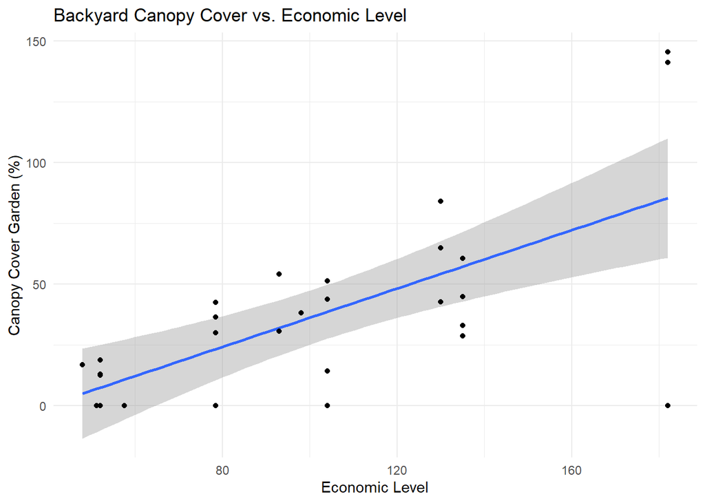

```r
canopy_ecomomic_plot <-
  ggplot(no_p22_data, aes(x = economic_level, y = canopy_cover_garden_maybepercentage)) +
  geom_smooth(method = "lm") +
  geom_point() +
  theme_minimal() +
  labs(x = "Economic Level",
       y = "Canopy Cover Garden (%)",
       title = "Backyard Canopy Cover vs. Economic Level")

canopy_ecomomic_plot
```

```r
ggsave(filename = paste0(IMAGE_FILE_PATH, "1-14_canopy-cover-vs-economic-level.png"),
       plot = canopy_ecomomic_plot)
```

Example figure caption: Relationship between backyard canopy cover (%) and economic level. The line represents the linear model fit with 95% confidence interval (shaded grey).

### Backyard Tree Biomass vs. Economic Level

```r
tree_biomass_ecomomic_lr <- lm(biomass_total_kg ~ economic_level, garden_data)
results_tree_biomass_ecomomic_lr <- summary(tree_biomass_ecomomic_lr)
results_tree_biomass_ecomomic_lr
```

```
##
## Call:
## lm(formula = biomass_total_kg ~ economic_level, data = garden_data)
##
## Residuals:
##     Min      1Q  Median      3Q     Max
## -5433.1 -2225.5  -798.1  -107.8 11766.3
##
## Coefficients:
##                Estimate Std. Error t value Pr(>|t|)
## (Intercept)    -1198.81    1863.91  -0.643   0.5253
## economic_level    36.44      17.45   2.089   0.0459 *
## ---
## Signif. codes:  0 '***' 0.001 '**' 0.01 '*' 0.05 '.' 0.1 ' ' 1
##
## Residual standard error: 3914 on 28 degrees of freedom
## Multiple R-squared:  0.1348, Adjusted R-squared:  0.1039
## F-statistic: 4.363 on 1 and 28 DF,  p-value: 0.04594
```

p-value: 0.0459

R-squared: 0.1348

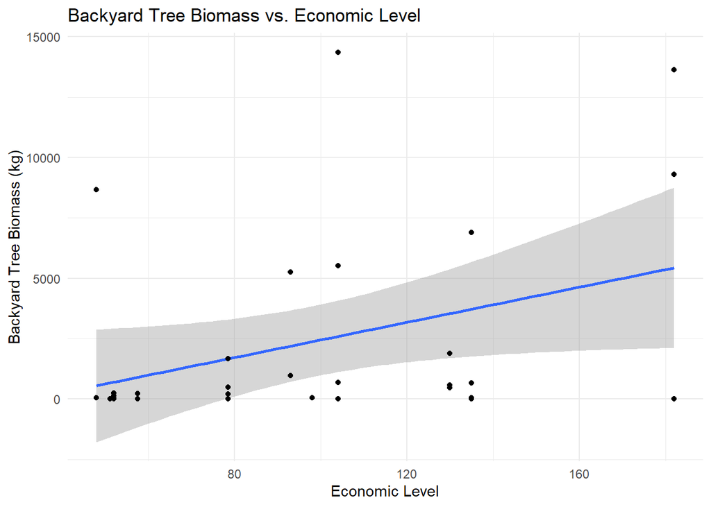

```r
garden_biomass_ecomomic_plot <-
  ggplot(garden_data, aes(x = economic_level, y = biomass_total_kg)) +
  geom_smooth(method = "lm") +
  geom_point() +
  theme_minimal() +
  labs(x = "Economic Level",
       y = "Backyard Tree Biomass (kg)",
       title = "Backyard Tree Biomass vs. Economic Level")

garden_biomass_ecomomic_plot
```

```r
ggsave(filename = paste0(IMAGE_FILE_PATH, "1-15_tree-biomass-vs-economic-level.png"),
       plot = garden_biomass_ecomomic_plot)
```

Example figure caption: Relationship between bacyard tree biomass (kg) and economic level. The line represents the linear model fit with 95% confidence interval (shaded grey).

### Total Backyard Plant Species Richness vs. Economic Level

Fit Poisson model since vegetation species richness is a count variable and checking for overdispersion. A Poisson model assumes equidispersion, where the variance of the response variable (vegetation species richness) is equal to its mean. In the case that its variance is greater than its mean, a negative binomial model should be used instead.

```r
no_m11_data <- garden_data |>
  filter(house != "M11")

veg_richness_ecomomic_poisson <-
  glm(overall_garden_diversity ~ economic_level,
      family = poisson,
      data = no_m11_data)
dispersiontest(veg_richness_ecomomic_poisson)
```

```
##
##  Overdispersion test
##
## data:  veg_richness_ecomomic_poisson
## z = 3.0826, p-value = 0.001026
## alternative hypothesis: true dispersion is greater than 1
## sample estimates:
## dispersion
##   5.172889
```

Since the dispersion test yields p-value = 0.001 < 0.05, there is overdispersion in the data and we’ll use a negative binomial model.

```r
veg_richness_ecomomic_nb <-
  glm.nb(overall_garden_diversity ~ economic_level,
      data = no_m11_data)
results_veg_richness_nb <- tidy(veg_richness_ecomomic_nb, exponentiate = TRUE)
results_veg_richness_nb
```

```
## # A tibble: 2 × 5
##   term           estimate std.error statistic  p.value
##   <chr>             <dbl>     <dbl>     <dbl>    <dbl>
## 1 (Intercept)       22.5    0.224      13.9   5.03e-44
## 2 economic_level     1.00   0.00207     0.590 5.55e- 1
```

p-value = 0.5549

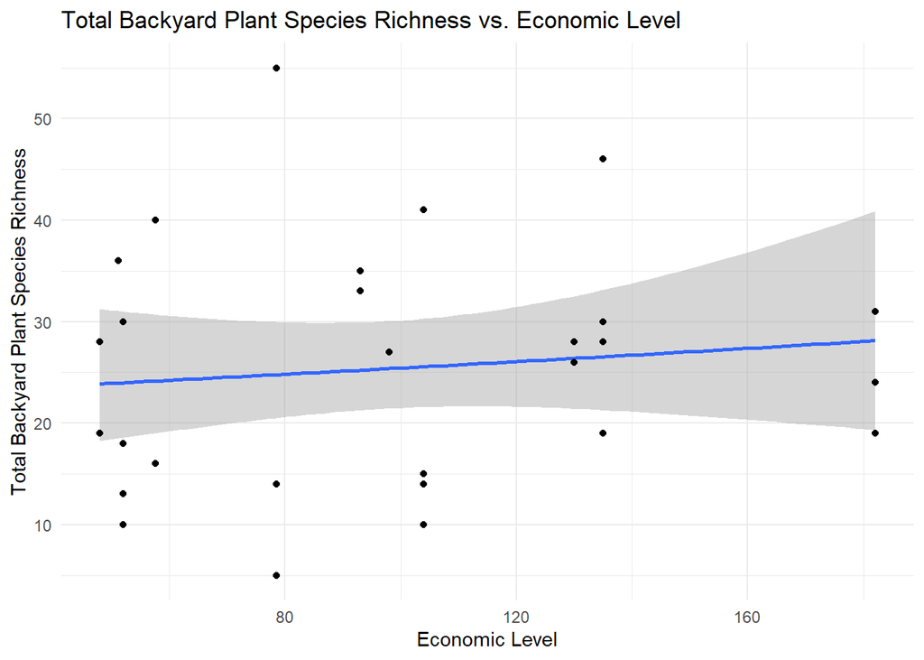

```r
veg_richness_plot <-
  ggplot(no_m11_data, aes(x = economic_level, y = overall_garden_diversity)) +
  geom_smooth(method = "glm.nb") +
  geom_point() +
  theme_minimal() +
  labs(x = "Economic Level",
       y = "Total Backyard Plant Species Richness",
       title = "Total Backyard Plant Species Richness vs. Economic Level")

veg_richness_plot
```

```r
ggsave(filename = paste0(IMAGE_FILE_PATH, "1-16_veg-richness-vs-economic-level.png"),
       plot = veg_richness_plot)
```

Example figure caption: Relationship between plant species richness and economic level. The line represents the negative binomial model fit with 95% confidence interval (shaded grey).

### Shannon Diversity in Terms of Canopy Percent Cover vs. Economic Level

```r
shannon_ecomomic_lr <- lm(shannon_index_per_garden_withpercentcover ~ economic_level, garden_data)
results_shannon_ecomomic_lr <- summary(shannon_ecomomic_lr)
results_shannon_ecomomic_lr
```

```
##
## Call:
## lm(formula = shannon_index_per_garden_withpercentcover ~ economic_level,
##     data = garden_data)
##
## Residuals:
##     Min      1Q  Median      3Q     Max
## -0.5414 -0.1460 -0.0117  0.1624  0.3777
##
## Coefficients:
##                  Estimate Std. Error t value Pr(>|t|)
## (Intercept)    -0.0112965  0.1060634  -0.107  0.91594
## economic_level  0.0030370  0.0009927   3.059  0.00485 **
## ---
## Signif. codes:  0 '***' 0.001 '**' 0.01 '*' 0.05 '.' 0.1 ' ' 1
##
## Residual standard error: 0.2227 on 28 degrees of freedom
## Multiple R-squared:  0.2505, Adjusted R-squared:  0.2238
## F-statistic: 9.359 on 1 and 28 DF,  p-value: 0.004848
```

p-value: 0.00485

R-squared: 0.2505

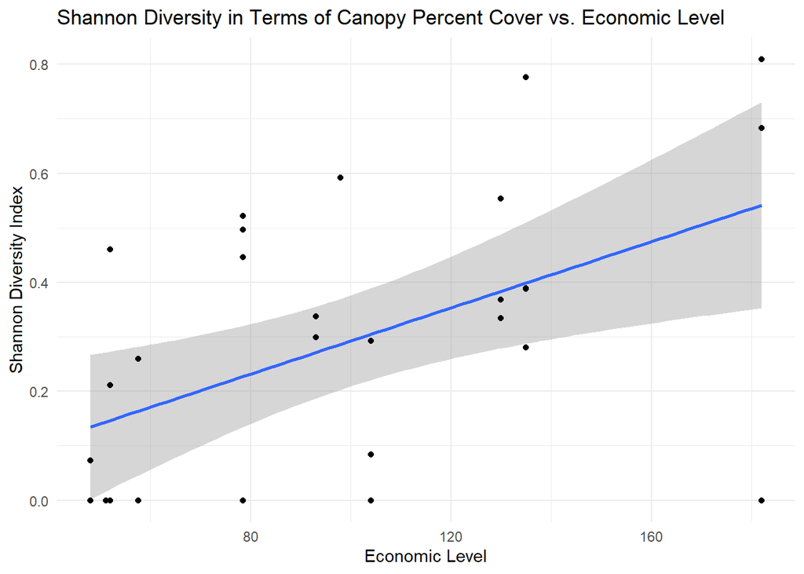

```r
shannon_ecomomic_plot <-
  ggplot(garden_data, aes(x = economic_level,
                          y = shannon_index_per_garden_withpercentcover)) +
  geom_smooth(method = "lm") +
  geom_point() +
  theme_minimal() +
  labs(x = "Economic Level",
       y = "Shannon Diversity Index",
       title = "Shannon Diversity in Terms of Canopy Percent Cover vs. Economic Level")

shannon_ecomomic_plot
```

```r
ggsave(filename = paste0(IMAGE_FILE_PATH, "1-18_shannon-diversity-vs-economic-level.png"),
       plot = shannon_ecomomic_plot)
```

Example figure caption: Relationship between Shannon Diversity Index in terms of canopy percent cover and economic level. The line represents the linear model fit with 95% confidence interval (shaded grey).

### ANOVA on Tree Species Richness Across Economic Groups

```r
# add economic group level names to data
garden_data <- garden_data |>
  mutate(economic_category = as.factor(str_sub(house, 1, 1)),
         economic_category = as.factor(
           case_when(
             economic_category == "P" ~ "Low",
             economic_category == "M" ~ "Medium",
             economic_category == "R" ~ "High"
             )
           ),
         # specify order of economic group levels
         economic_category = fct_relevel(economic_category, c("Low", "Medium", "High")))
```

ANOVA:

```r
tree_richness_economic_anova <- aov(tree_species_richness ~ economic_category, garden_data)
results_tree_richness_economic_anova <- summary(tree_richness_economic_anova)
results_tree_richness_economic_anova
```

```
##                   Df Sum Sq Mean Sq F value Pr(>F)
## economic_category  2   95.0   47.50   4.409  0.022 *
## Residuals         27  290.9   10.77
## ---
## Signif. codes:  0 '***' 0.001 '**' 0.01 '*' 0.05 '.' 0.1 ' ' 1
```

df (degrees of freedom): 2

Residual: 27

F: 4.409

p-value: 0.022

**Check assumptions (1) normality of residuals using a Shapiro-Wilk normality test and (2) equal variance of each group using a Levene’s test.**

```r
shapiro.test(tree_richness_economic_anova$residuals)
```

```
##
##  Shapiro-Wilk normality test
##
## data:  tree_richness_economic_anova$residuals
## W = 0.95523, p-value = 0.2328
```

```r
leveneTest(tree_species_richness ~ economic_category, garden_data)
```

```
## Levene's Test for Homogeneity of Variance (center = median)
##       Df F value Pr(>F)
## group  2  2.4153 0.1084
##       27
```

Neither assumption is violated (p-values > 0.05).

Plot:

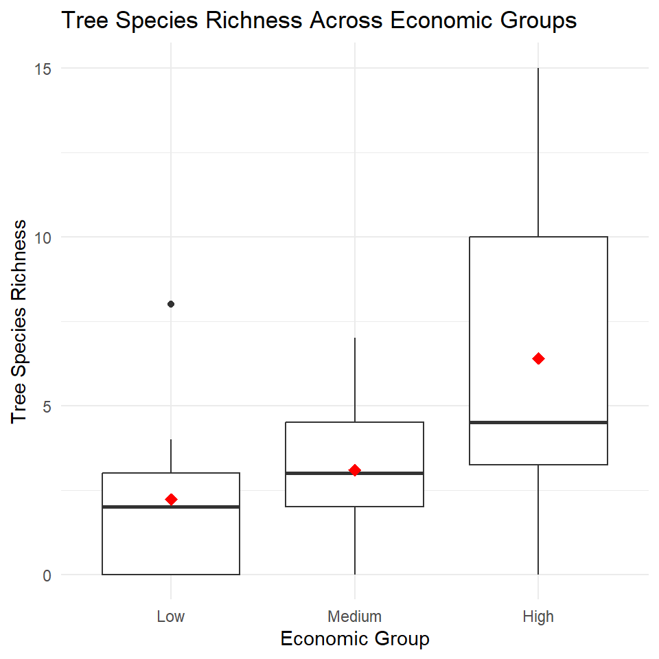

```r
tree_richness_economic_plot <-
  ggplot(garden_data, aes(x = economic_category, y = tree_species_richness)) +
  geom_boxplot() +
  theme_minimal() +
  stat_summary(fun = mean, geom = "point", shape = 18, size = 3, color = "red") +
  labs(x = "Economic Group",
       y = "Tree Species Richness",
       title = "Tree Species Richness Across Economic Groups")

tree_richness_economic_plot
```

```r
ggsave(filename = paste0(IMAGE_FILE_PATH, "1-19_tree-richness-vs-economic-level.png"),
       plot = tree_richness_economic_plot,
       height = 5,
       width = 5)
```

Example figure caption: Tree species richness observed per economic group. Boxplots represent the mean (red diamond), median (bold horizontal line), interquartile range (boxes), and 1.5 interquartile range (whiskers).

## Chapter 2

To investigate how bird species richness is associated with vegetation composition and structure in private urban forests, Poisson regression models were fitted with bird species richness as the response variable and the following predictors per backyard: canopy cover, plant species richness, and native plant proportion. Equidispersion was verified using a dispersion test, confirming that Poisson models were appropriate. Three points were excluded from the analysis due to low bird detections attributed to recording issues.

A bird species accumulation curve was constructed by randomly ordering houses and cumulatively recording the number of new species detected with each additional house sampled. This process was repeated 100 times with different random orderings, and the mean cumulative species richness along with the 95% confidence interval across permutations were calculated.

Vegetation and bird variables, both raw and standardized per backyard area, were tested using linear models with economic level as the independent variable.

### Bird Species Richness vs. Backyard Canopy Cover

```r
no_p21_m13_m11 <- garden_data |>
  filter(!house %in% c("P21", "M13", "M11"))

bird_canopy_poisson <-
  glm(bird_diversity ~ canopy_cover_garden_maybepercentage,
      family = poisson,
      data = no_p21_m13_m11)
dispersiontest(bird_canopy_poisson)
```

```
##
##  Overdispersion test
##
## data:  bird_canopy_poisson
## z = 0.84021, p-value = 0.2004
## alternative hypothesis: true dispersion is greater than 1
## sample estimates:
## dispersion
##   2.112783
```

p-value = 0.2004 > 0.05, there is no significant overdispersion.

```r
results_bird_canopy_poisson <- tidy(bird_canopy_poisson, exponentiate = TRUE)
results_bird_canopy_poisson
```

```
## # A tibble: 2 × 5
##   term                                estimate std.error statistic p.value
##   <chr>                                  <dbl>     <dbl>     <dbl>   <dbl>
## 1 (Intercept)                            38.3   0.0454      80.3     0
## 2 canopy_cover_garden_maybepercentage     1.00  0.000735     0.788   0.431
```

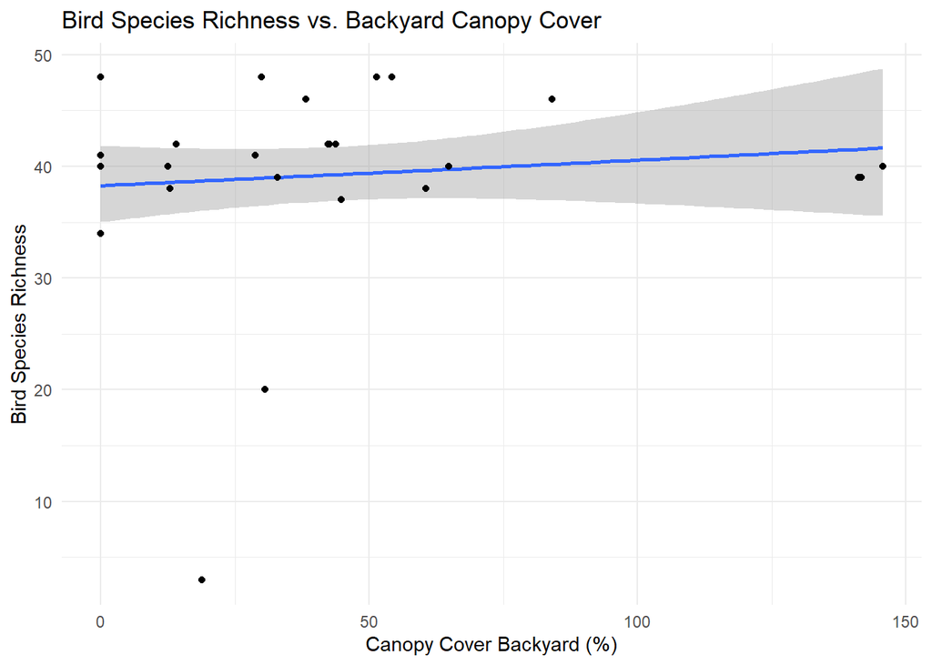

```r
bird_canopy_plot <-
  ggplot(no_p21_m13_m11, aes(x = canopy_cover_garden_maybepercentage,
                          y = bird_diversity)) +
  geom_smooth(method = "glm", method.args = list(family = "poisson")) +
  geom_point() +
  theme_minimal() +
  labs(x = "Canopy Cover Backyard (%)",
       y = "Bird Species Richness",
       title = "Bird Species Richness vs. Backyard Canopy Cover")

bird_canopy_plot
```

```r
ggsave(filename = paste0(IMAGE_FILE_PATH, "2-21_bird-vs-canopy.png"),
       plot = bird_canopy_plot)
```

Example figure caption: Relationship between bird species richness and backyard canopy cover (%). The line represents the Poisson model fit with 95% confidence interval (shaded grey).

### Bird Species Richness vs. Backyard Plant Species Richness

```r
bird_veg_poisson <-
  glm(bird_diversity ~ overall_garden_diversity,
      family = "poisson",
      data = no_p21_m13_m11)
dispersiontest(bird_veg_poisson)
```

```
##
##  Overdispersion test
##
## data:  bird_veg_poisson
## z = 0.86101, p-value = 0.1946
## alternative hypothesis: true dispersion is greater than 1
## sample estimates:
## dispersion
##   2.099681
```

p-value = 0.1946 > 0.05, there is no significant overdispersion.

```r
results_bird_veg_poisson <- tidy(bird_veg_poisson, exponentiate = TRUE)
results_bird_veg_poisson
```

```
## # A tibble: 2 × 5
##   term                     estimate std.error statistic p.value
##   <chr>                       <dbl>     <dbl>     <dbl>   <dbl>
## 1 (Intercept)                 38.1    0.0798     45.6     0
## 2 overall_garden_diversity     1.00   0.00277     0.331   0.741
```

p-value = 0.7407

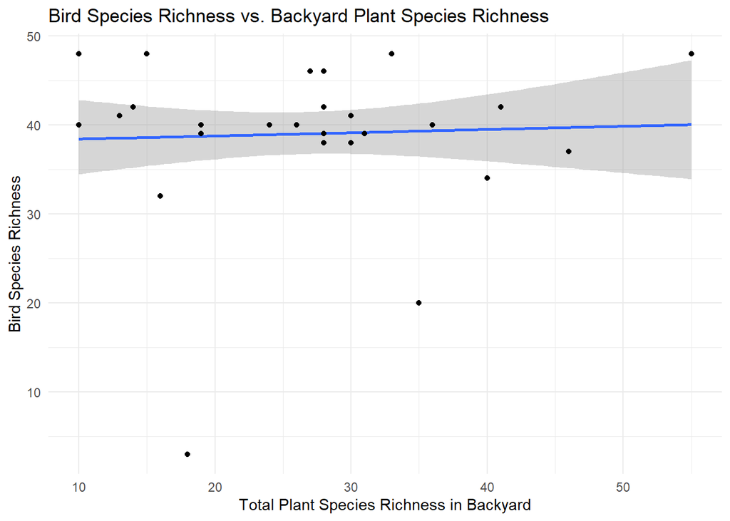

```r
bird_veg_plot <-
  ggplot(no_p21_m13_m11, aes(x = overall_garden_diversity,
                          y = bird_diversity)) +
  geom_smooth(method = "glm", method.args = list(family = "poisson")) +
  geom_point() +
  theme_minimal() +
  labs(x = "Total Plant Species Richness in Backyard",
       y = "Bird Species Richness",
       title = "Bird Species Richness vs. Backyard Plant Species Richness")

bird_veg_plot
```

```r
ggsave(filename = paste0(IMAGE_FILE_PATH, "2-22_bird-vs-veg-richness.png"),
       plot = bird_veg_plot)
```

Example figure caption: Relationship between bird species richness and plant species richness. The line represents the Poisson model fit with 95% confidence interval (shaded grey).

### Bird Species Richness vs. Native Plant Proportion

```r
# add native percentage to garden data
native_percent <- read_excel(GARDEN_FILE_PATH, sheet='Native_vs_not_GRAPHING') |>
  select(House, Native_percent_total) |>
  clean_names() # clean column names

no_p21_m13_m11 <- no_p21_m13_m11 |>
  left_join(native_percent, by = join_by(house))
```

```r
bird_native_poisson <-
  glm(bird_diversity ~ native_percent_total,
      family = poisson,
      data = no_p21_m13_m11)
dispersiontest(bird_native_poisson)
```

```
##
##  Overdispersion test
##
## data:  bird_native_poisson
## z = 0.79855, p-value = 0.2123
## alternative hypothesis: true dispersion is greater than 1
## sample estimates:
## dispersion
##   2.034498
```

p-value = 0.2123 > 0.05, there is no significant overdispersion.

```r
results_bird_native_poisson <- tidy(bird_native_poisson, exponentiate = TRUE)
results_bird_native_poisson
```

```
## # A tibble: 2 × 5
##   term                 estimate std.error statistic p.value
##   <chr>                   <dbl>     <dbl>     <dbl>   <dbl>
## 1 (Intercept)            41.0     0.0532      69.7    0
## 2 native_percent_total    0.995   0.00460     -1.13   0.260
```

p-value = 0.2599

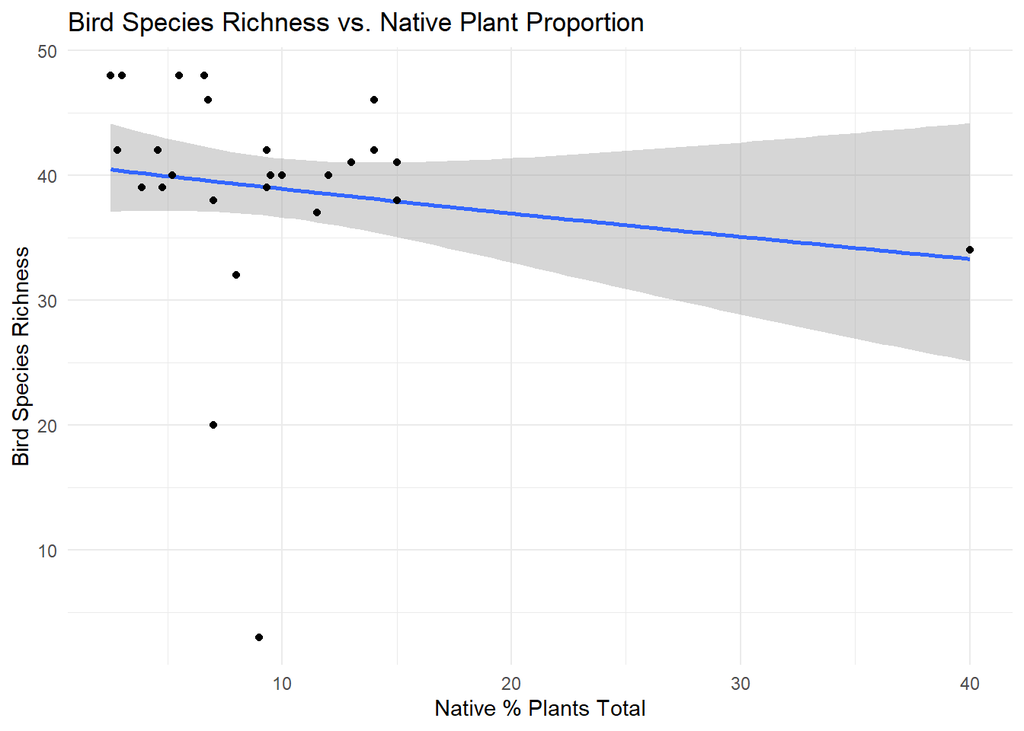

```r
bird_native_plot <-
  ggplot(no_p21_m13_m11, aes(x = native_percent_total,
                          y = bird_diversity)) +
  geom_smooth(method = "glm", method.args = list(family = "poisson")) +
  geom_point() +
  theme_minimal() +
  labs(x = "Native % Plants Total",
       y = "Bird Species Richness",
       title = "Bird Species Richness vs. Native Plant Proportion")

bird_native_plot
```

```r
ggsave(filename = paste0(IMAGE_FILE_PATH, "2-23_bird-vs-native.png"),
       plot = bird_native_plot)
```

Example figure caption: Relationship between bird species richness and native proportion of plants (%). The line represents the Poisson model fit with 95% confidence interval (shaded grey).

### Accumulation curve accross houses

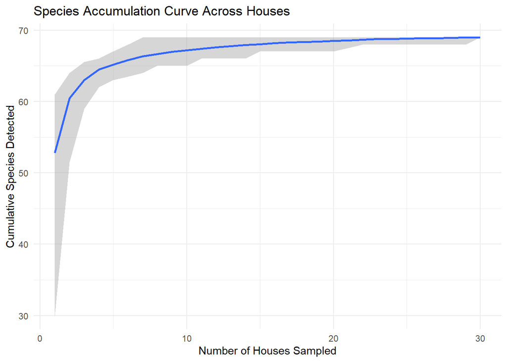

```r
set.seed(123) # set seed for reproducible permutations

# presence/absence matrix where rows = houses and columns = species
presence_matrix <- bird_data |>
  count(house, species) |>
  pivot_wider(names_from = species, values_from = n, values_fill = 0) |>
  column_to_rownames("house") |>
  mutate(across(everything(), ~ as.integer(. > 0)))

# species accumulation curve
n_permutations <- 100
houses <- rownames(presence_matrix)
n_houses <- length(houses)
n_species <- ncol(presence_matrix)

curves <- matrix(0, nrow = n_permutations, ncol = n_houses)

for (i in seq_len(n_permutations)) {
  perm <- sample(houses)
  seen <- rep(FALSE, n_species)

  for (j in seq_along(perm)) {
    seen <- seen | as.logical(presence_matrix[perm[j], ])
    curves[i, j] <- sum(seen)
  }
}

# summarise across permutations
results <- tibble(
  x          = seq_len(n_houses),
  mean_curve = colMeans(curves),
  lower      = apply(curves, 2, quantile, probs = 0.025),
  upper      = apply(curves, 2, quantile, probs = 0.975)
)

# plot
accumulation_plot <- ggplot(results, aes(x = x)) +
  geom_ribbon(aes(ymin = lower, ymax = upper), fill = "grey60", alpha = 0.4) +
  geom_line(aes(y = mean_curve), color = "#3366FF", linewidth = 1) +
  labs(
    title = "Species Accumulation Curve Across Houses",
    x     = "Number of Houses Sampled",
    y     = "Cumulative Species Detected"
  ) +
  theme_minimal()

accumulation_plot
```

```r
ggsave(filename = paste0(IMAGE_FILE_PATH, "2-24_accumulation-plot.png"),
       plot = accumulation_plot)
```

Example figure caption: Bird species accumulation curve based on 100 random permutations of houses. The line represents the mean cumulative species richness and with the 95% confidence interval (shaded grey).

### Panel comparing vegetation and birds variables vs economic level and the same over area of backyard

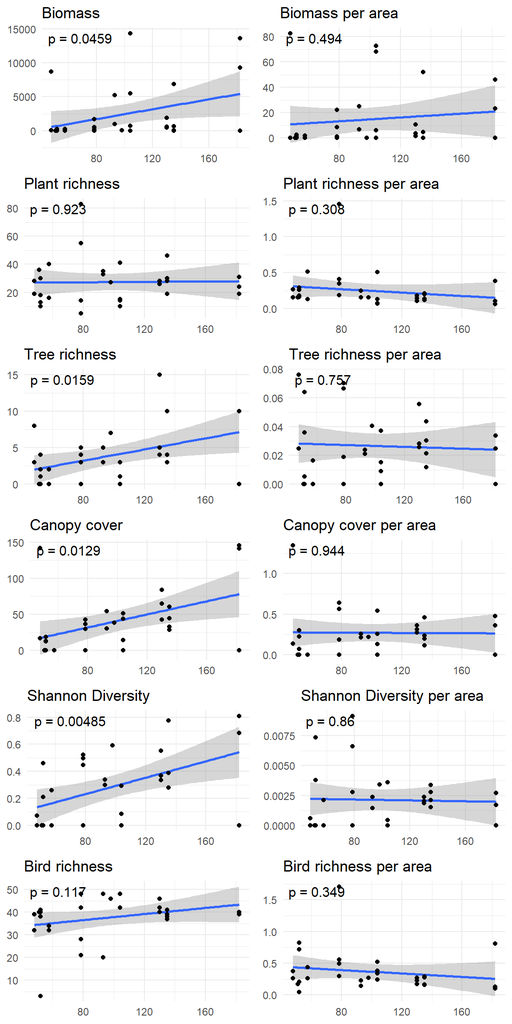

```r
garden_data <- garden_data |>
  mutate(biomass_per_m2 = biomass_total_kg/garden_size_m_2,
         plants_per_m2 = overall_garden_diversity/garden_size_m_2,
         trees_per_m2 = tree_species_richness/garden_size_m_2,
         canopy_per_m2 = canopy_cover_garden_maybepercentage/garden_size_m_2,
         shannon_index_per_garden_withpercentcover_per_m2 = shannon_index_per_garden_withpercentcover/garden_size_m_2,
         birds_per_m2 = bird_diversity/garden_size_m_2
         )

y_vars <- c("biomass_total_kg", "biomass_per_m2",
            "overall_garden_diversity", "plants_per_m2",
            "tree_species_richness", "trees_per_m2",
            "canopy_cover_garden_maybepercentage", "canopy_per_m2",
            "shannon_index_per_garden_withpercentcover", "shannon_index_per_garden_withpercentcover_per_m2",
            "bird_diversity", "birds_per_m2")
titles <- c("Biomass", "Biomass per area",
            "Plant richness", "Plant richness per area",
            "Tree richness", "Tree richness per area",
            "Canopy cover", "Canopy cover per area",
            "Shannon Diversity", "Shannon Diversity per area",
            "Bird richness", "Bird richness per area")

plots <- map2(y_vars, titles, \(var, title) {
  # compute p-value for the slope of economic_level
  p <- tidy(lm(garden_data[[var]] ~ garden_data$economic_level))$p.value[2]
  p_label <- paste0("p = ", signif(p, 3))

  ggplot(garden_data, aes(x = economic_level, y = .data[[var]])) +
    geom_smooth(method = "lm") +
    geom_point() +
    theme_minimal() +
    annotate("text", x = -Inf, y = Inf, label = p_label,
             hjust = -0.1, vjust = 1.5, size = 4) +
    labs(y = NULL, x = NULL, title = title)
})

panel_plot <- plot_grid(plotlist = plots, ncol = 2)
panel_plot
```

```r
ggsave(filename = paste0(IMAGE_FILE_PATH, "2-25_panel-plot.png"),
       plot = panel_plot,
       height = 12,
       width = 6)
```

Example figure caption: Relationship between biomass, plant species richness, canopy cover, and bird species richness (raw and area standardized per backyard area) against economic level. The line represents the linear model fit with 95% confidence interval (shaded grey).

## Other

To test whether tree height and average tree height per house differed across economic groups, normality and homogeneity of variances were assessed using the Shapiro-Wilk and Levene’s tests, respectively. As normality was violated, a Kruskal-Wallis test was used as a non-parametric alternative. An outlier was removed from the analysis and plots.

### Tree height per economic group

```r
tree_height <- read_excel(GARDEN_FILE_PATH, sheet='Tree_per_garden') |>
  select(ID, `Ht (m)`) |>
  clean_names() |>
  left_join(garden_data[, c("house", "economic_category", "economic_level")], by = c("id" = "house")) |>
  filter(id != "P22") # remove outlier
```

ANOVA:

```r
tree_height_economic_anova <- aov(ht_m ~ economic_category, tree_height)
```

**Check assumptions (1) normality of residuals using a Shapiro-Wilk normality test and (2) equal variance of each group using a Levene’s test.**

```r
shapiro.test(tree_height_economic_anova$residuals)
```

```
##
##  Shapiro-Wilk normality test
##
## data:  tree_height_economic_anova$residuals
## W = 0.63888, p-value = 5.476e-15
```

```r
leveneTest(ht_m ~ economic_category, tree_height)
```

```
## Levene's Test for Homogeneity of Variance (center = median)
##        Df F value Pr(>F)
## group   2  1.6404 0.1988
##       106
```

The assumption of normally distributed residuals is violated (p-value < 0.05) while the assumption of variance is not (p-value > 0.05). Therefore, a Kruskal-Wallis test is more appropriate to compare the **median** of each group instead of the **mean**. The medians better reflects the central tendency in the case of outliers and skewedness. Additionally, the Kruskal-Wallis test does not make assumptions about the data distribution or variablility.

Kruskal-Wallis Test:

```r
kruskal.test(ht_m ~ economic_category, data = tree_height)
```

```
##
##  Kruskal-Wallis rank sum test
##
## data:  ht_m by economic_category
## Kruskal-Wallis chi-squared = 7.6294, df = 2, p-value = 0.02204
```

There is a statistically significant difference in median tree height across economic categories (p = 0.022 < 0.05).

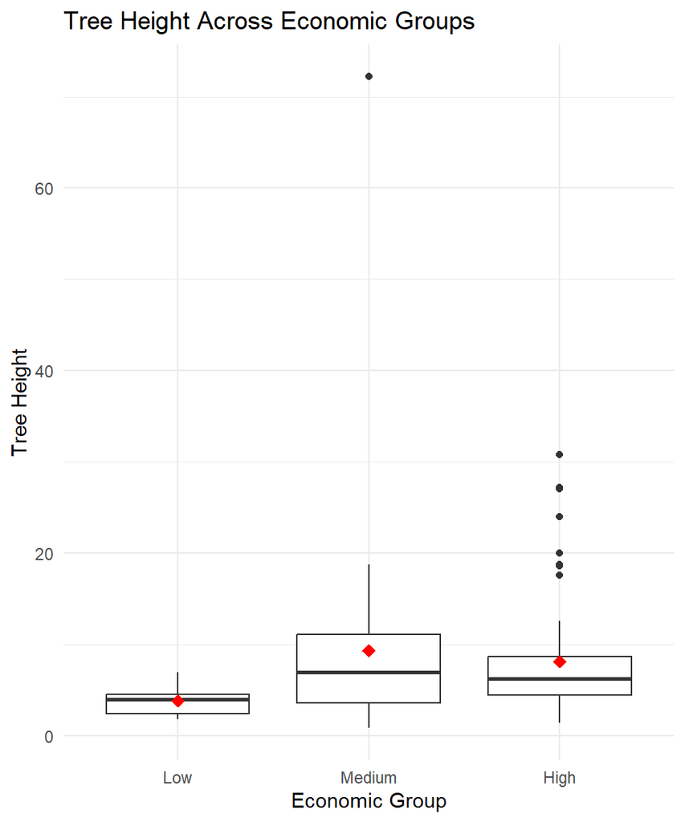

```r
tree_height_economic_plot <-
  ggplot(tree_height, aes(x = economic_category, y = ht_m)) +
  geom_boxplot() +
  stat_summary(fun = mean, geom = "point", shape = 18, size = 3, color = "red") +
  theme_minimal() +
  labs(x = "Economic Group",
       y = "Tree Height",
       title = "Tree Height Across Economic Groups")

tree_height_economic_plot
```

```r
ggsave(filename = paste0(IMAGE_FILE_PATH, "other-1_tree-height-vs-economic-level.png"),
      plot = tree_height_economic_plot,
      height = 6,
      width = 6)
```

Example figure caption: Tree height observed per economic group. Boxplots represent the mean (red diamond), median (bold horizontal line), interquartile range (boxes), and 1.5 interquartile range (whiskers).

#### Linear Regression of Tree Height vs. Economic Level

```r
tree_height_lr <- lm(ht_m ~ economic_level, data = tree_height)
results_tree_height_lr <- summary(tree_height_lr)
results_tree_height_lr
```

```
##
## Call:
## lm(formula = ht_m ~ economic_level, data = tree_height)
##
## Residuals:
##    Min     1Q Median     3Q    Max
## -7.450 -4.135 -1.735  1.399 64.942
##
## Coefficients:
##                Estimate Std. Error t value Pr(>|t|)
## (Intercept)     1.75055    2.55824   0.684   0.4953
## economic_level  0.05296    0.02038   2.599   0.0107 *
## ---
## Signif. codes:  0 '***' 0.001 '**' 0.01 '*' 0.05 '.' 0.1 ' ' 1
##
## Residual standard error: 8.334 on 107 degrees of freedom
## Multiple R-squared:  0.05938,    Adjusted R-squared:  0.05059
## F-statistic: 6.755 on 1 and 107 DF,  p-value: 0.01067
```

p-value: 0.0107

R-squared: 0.05938

I do not suggest using this model since there does not seem to be linearity in the coefficients, the residuals vs. fitted points does not show a cloud. Also, the Q-Q Residuals does not show normality of the error term since the points do not follow the 45 degree line.

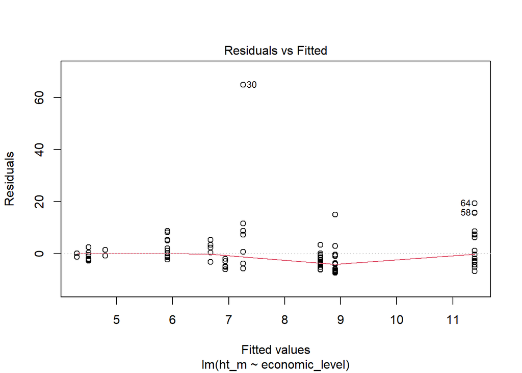

```r
plot(tree_height_lr, 1)
```

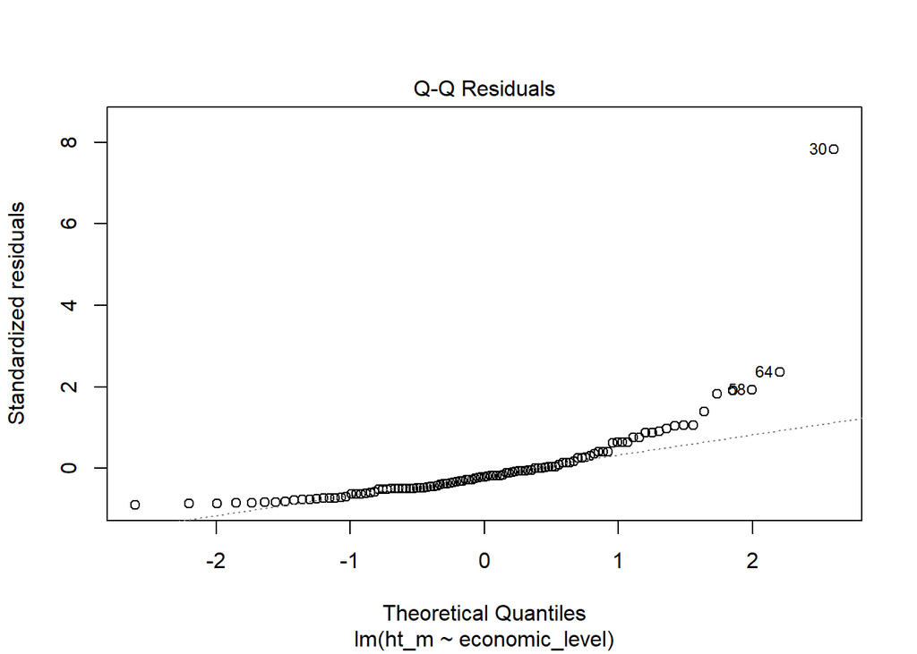

```r
plot(tree_height_lr, 2)
```

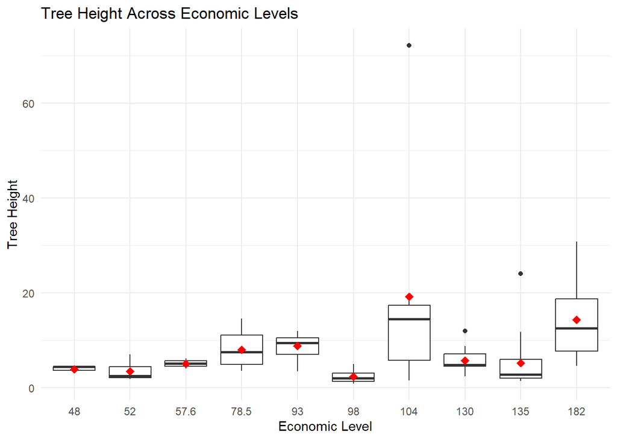

```r
tree_height_economic_box_plot <-
  ggplot(tree_height, aes(x = as.factor(economic_level), y = ht_m)) +
  geom_boxplot() +
  stat_summary(fun = mean, geom = "point", shape = 18, size = 3, color = "red") +
  theme_minimal() +
  labs(x = "Economic Level",
       y = "Tree Height",
       title = "Tree Height Across Economic Levels")

tree_height_economic_box_plot
```

```r
ggsave(filename = paste0(IMAGE_FILE_PATH, "other-1_boxplot-tree-height-vs-economic-level.png"),
       plot = tree_height_economic_box_plot)
```

Example figure caption: Tree height observed per economic level. Boxplots represent the mean (red diamond), median (bold horizontal line), interquartile range (boxes), and 1.5 interquartile range (whiskers).

NOTE: I don’t really recommend using a box plot for this, since there are a differing amount of observations per economic level, and the box plot hides individual observations.

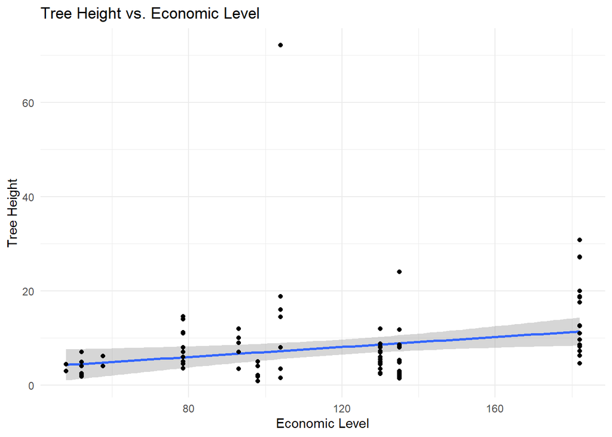

```r
tree_height_ecomomic_lr_plot <-
  ggplot(tree_height, aes(x = economic_level, y = ht_m)) +
  geom_smooth(method = "lm") +
  geom_point() +
  theme_minimal() +
  labs(x = "Economic Level",
       y = "Tree Height",
       title = "Tree Height vs. Economic Level")

tree_height_ecomomic_lr_plot
```

```r
ggsave(filename = paste0(IMAGE_FILE_PATH, "other-1_line-tree-height-vs-economic-level.png"),
       plot = tree_height_ecomomic_lr_plot)
```

Example figure caption: Relationship between tree height (m) and economic level. The line represents the linear model fit with 95% confidence interval (shaded grey).

### Average tree height per house per economic group

```r
average_tree_height_per_house <- tree_height |>
  group_by(id, economic_category, economic_level) |>
  summarize(average_tree_height = mean(ht_m))
```

```
## `summarise()` has regrouped the output.
## ℹ Summaries were computed grouped by id, economic_category, and economic_level.
## ℹ Output is grouped by id and economic_category.
## ℹ Use `summarise(.groups = "drop_last")` to silence this message.
## ℹ Use `summarise(.by = c(id, economic_category, economic_level))` for
##   per-operation grouping (`?dplyr::dplyr_by`) instead.
```

```r
avg_tree_height_economic_anova <-
  aov(average_tree_height ~ economic_category, average_tree_height_per_house)
```

**Check assumptions (1) normality of residuals using a Shapiro-Wilk normality test and (2) equal variance of each group using a Levene’s test.**

```r
shapiro.test(avg_tree_height_economic_anova$residuals)
```

```
##
##  Shapiro-Wilk normality test
##
## data:  avg_tree_height_economic_anova$residuals
## W = 0.74432, p-value = 5.574e-05
```

```r
leveneTest(average_tree_height ~ economic_category, data = average_tree_height_per_house)
```

```
## Levene's Test for Homogeneity of Variance (center = median)
##       Df F value Pr(>F)
## group  2  0.5168 0.6042
##       20
```

Again, the assumption of normally distributed residuals is violated (p-value < 0.05) while the assumption of variance is not (p-value > 0.05). Therefore, a Kruskal-Wallis test again to compare the **median** of each group instead of the **mean**.

Kruskal-Wallis Test:

```r
kruskal.test(average_tree_height ~ economic_category, data = average_tree_height_per_house)
```

```
##
##  Kruskal-Wallis rank sum test
##
## data:  average_tree_height by economic_category
## Kruskal-Wallis chi-squared = 5.4831, df = 2, p-value = 0.06447
```

The median of average tree height per house did not differ significantly across economic categories (p-value = 0.064 > 0.05).

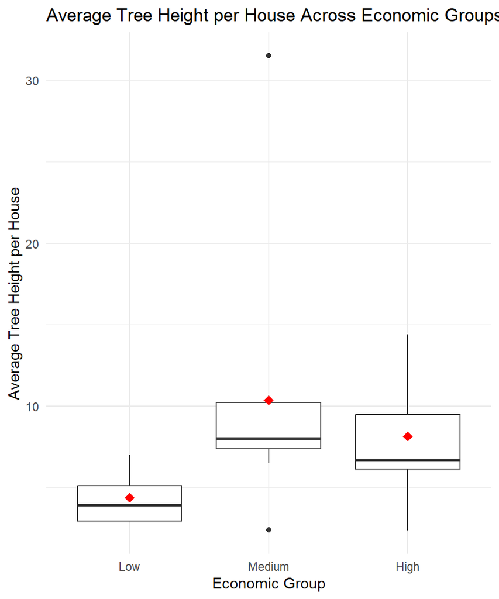

```r
avg_tree_height_economic_plot <-
  ggplot(average_tree_height_per_house, aes(x = economic_category, y = average_tree_height)) +
  geom_boxplot() +
  stat_summary(fun = mean, geom = "point", shape = 18, size = 3, color = "red") +
  theme_minimal() +
  labs(x = "Economic Group",
       y = "Average Tree Height per House",
       title = "Average Tree Height per House Across Economic Groups")

avg_tree_height_economic_plot
```

```r
ggsave(filename = paste0(IMAGE_FILE_PATH, "other-2_average-tree-height-per-house-vs-economic-level.png"),
      plot = avg_tree_height_economic_plot,
      height = 6,
      width = 6)
```

Example figure caption: Average tree height per house observed per economic group. Boxplots represent the mean (red diamond), median (bold horizontal line), interquartile range (boxes), and 1.5 interquartile range (whiskers).

#### Linear Regression of Average Tree Height vs. Economic Level

```r
avg_tree_height_lr <- lm(average_tree_height ~ economic_level, data = average_tree_height_per_house)
results_avg_tree_height_lr <- summary(avg_tree_height_lr)
results_avg_tree_height_lr
```

```
##
## Call:
## lm(formula = average_tree_height ~ economic_level, data = average_tree_height_per_house)
##
## Residuals:
##     Min      1Q  Median      3Q     Max
## -7.3369 -2.7631 -0.8395  1.5886 23.3050
##
## Coefficients:
##                Estimate Std. Error t value Pr(>|t|)
## (Intercept)     3.13966    3.54331   0.886    0.386
## economic_level  0.04861    0.03203   1.517    0.144
##
## Residual standard error: 5.878 on 21 degrees of freedom
## Multiple R-squared:  0.09882,    Adjusted R-squared:  0.0559
## F-statistic: 2.303 on 1 and 21 DF,  p-value: 0.1441
```

p-value: 0.144

R-squared: 0.09882

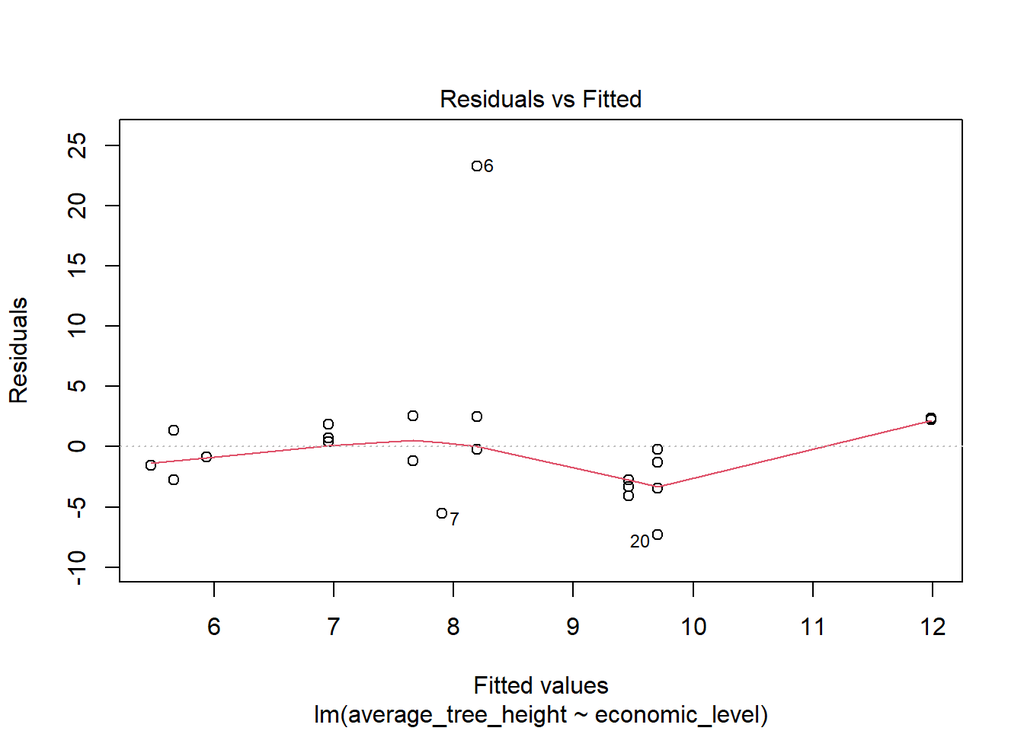

```r
plot(avg_tree_height_lr, 1)
```

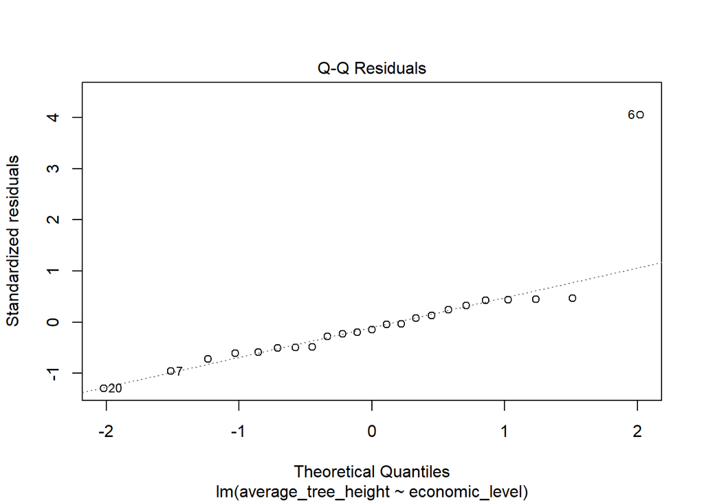

```r
plot(avg_tree_height_lr, 2)
```

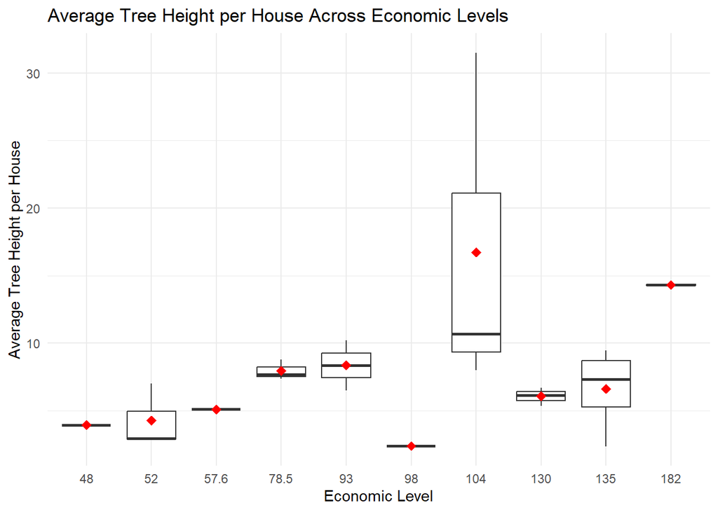

```r
avg_tree_height_economic_box_plot <-
  ggplot(average_tree_height_per_house, aes(x = as.factor(economic_level), y = average_tree_height)) +
  geom_boxplot() +
  stat_summary(fun = mean, geom = "point", shape = 18, size = 3, color = "red") +
  theme_minimal() +
  labs(x = "Economic Level",
       y = "Average Tree Height per House",
       title = "Average Tree Height per House Across Economic Levels")

avg_tree_height_economic_box_plot
```

```r
ggsave(filename = paste0(IMAGE_FILE_PATH, "other-2_boxplot-average-tree-height-vs-economic-level.png"),
       plot = avg_tree_height_economic_box_plot)
```

Example figure caption: Average tree height per house observed per economic level. Boxplots represent the mean (red diamond), median (bold horizontal line), interquartile range (boxes), and 1.5 interquartile range (whiskers).

NOTE: I don’t really recommend using a box plot for this, since there are little amount of observations/houses per economic level, and the box plot can imply that there are more observations than there are.

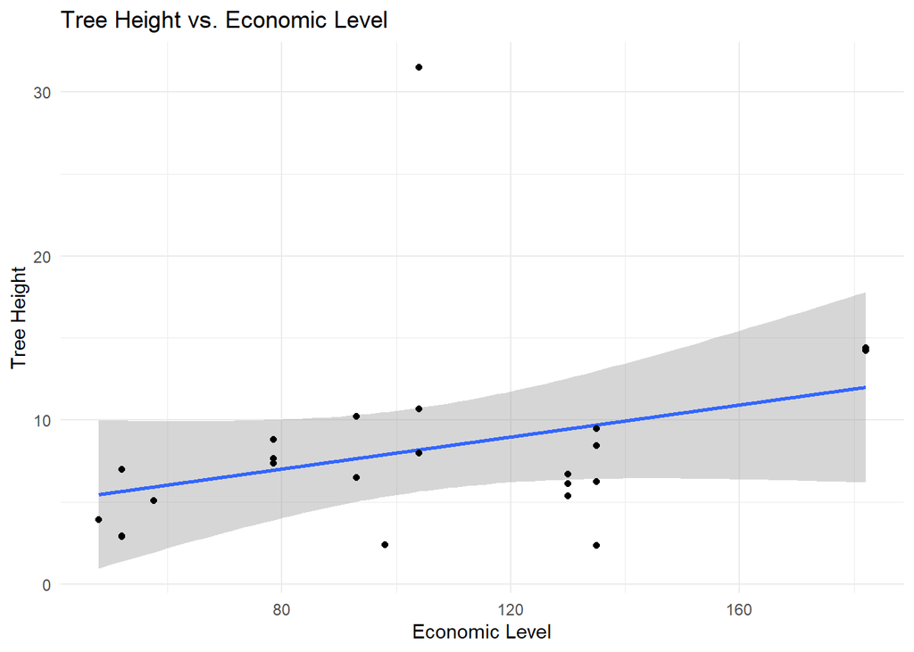

```r
avg_tree_height_ecomomic_lr_plot <-
  ggplot(average_tree_height_per_house, aes(x = economic_level, y = average_tree_height)) +
  geom_smooth(method = "lm") +
  geom_point() +
  theme_minimal() +
  labs(x = "Economic Level",
       y = "Tree Height",
       title = "Tree Height vs. Economic Level")

avg_tree_height_ecomomic_lr_plot
```

```r
ggsave(filename = paste0(IMAGE_FILE_PATH, "other-2_line-average-tree-height-vs-economic-level.png"),
       plot = avg_tree_height_ecomomic_lr_plot)
```

Example figure caption: Relationship between average tree height per house (m) and economic level. The line represents the linear model fit with 95% confidence interval (shaded grey).

### Backyard Coniferous Canopy Cover vs. Economic Level

Note: only 12 backyards have coniferous trees

```r
con_canopy_ecomomic_lr <- lm(coniferous_canopy ~ economic_level, no_p22_data)
results_con_canopy_ecomomic_lr <- summary(con_canopy_ecomomic_lr)
results_con_canopy_ecomomic_lr
```

```
##
## Call:
## lm(formula = coniferous_canopy ~ economic_level, data = no_p22_data)
##
## Residuals:
##     Min      1Q  Median      3Q     Max
## -89.472 -30.429   0.655   9.539 185.347
##
## Coefficients:
##                Estimate Std. Error t value Pr(>|t|)
## (Intercept)    -48.2957    28.3046  -1.706  0.09943 .
## economic_level   0.7570     0.2613   2.896  0.00739 **
## ---
## Signif. codes:  0 '***' 0.001 '**' 0.01 '*' 0.05 '.' 0.1 ' ' 1
##
## Residual standard error: 57.07 on 27 degrees of freedom
## Multiple R-squared:  0.2371, Adjusted R-squared:  0.2088
## F-statistic: 8.389 on 1 and 27 DF,  p-value: 0.007394
```

p-value: 0.00739

R-squared: 0.2371

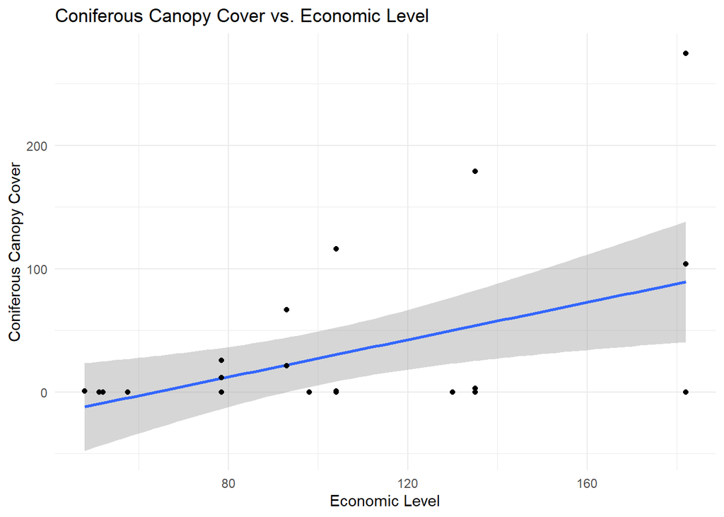

```r
con_canopy_ecomomic_plot <-
  ggplot(no_p22_data, aes(x = economic_level, y = coniferous_canopy)) +
  geom_smooth(method = "lm") +
  geom_point() +
  theme_minimal() +
  labs(x = "Economic Level",
       y = "Coniferous Canopy Cover",
       title = "Coniferous Canopy Cover vs. Economic Level")

con_canopy_ecomomic_plot
```

```r
ggsave(filename = paste0(IMAGE_FILE_PATH,
                         "other-3_coniferous-canopy-cover-vs-economic-level.png"),
       plot = con_canopy_ecomomic_plot)
```

Example figure caption: Relationship between coniferous canopy cover and economic level. The line represents the linear model fit with 95% confidence interval (shaded grey).

### Bird Species Richness vs. Backyard Coniferous Canopy Cover

Note: only 12 backyards have coniferous trees.

```r
bird_con_canopy_poisson <-
  glm(bird_diversity ~ coniferous_canopy,
      family = poisson,
      data = no_p21_m13_m11)
dispersiontest(bird_con_canopy_poisson)
```

```
##
##  Overdispersion test
##
## data:  bird_con_canopy_poisson
## z = 0.86303, p-value = 0.1941
## alternative hypothesis: true dispersion is greater than 1
## sample estimates:
## dispersion
##   2.098928
```

p-value = 0.1941 > 0.05, there is no significant overdispersion.

```r
results_bird_con_canopy_poisson <- tidy(bird_con_canopy_poisson, exponentiate = TRUE)
results_bird_con_canopy_poisson
```

```
## # A tibble: 2 × 5
##   term              estimate std.error statistic p.value
##   <chr>                <dbl>     <dbl>     <dbl>   <dbl>
## 1 (Intercept)          38.7   0.0343     106.      0
## 2 coniferous_canopy     1.00  0.000343     0.532   0.595
```

p-value: 0.5946

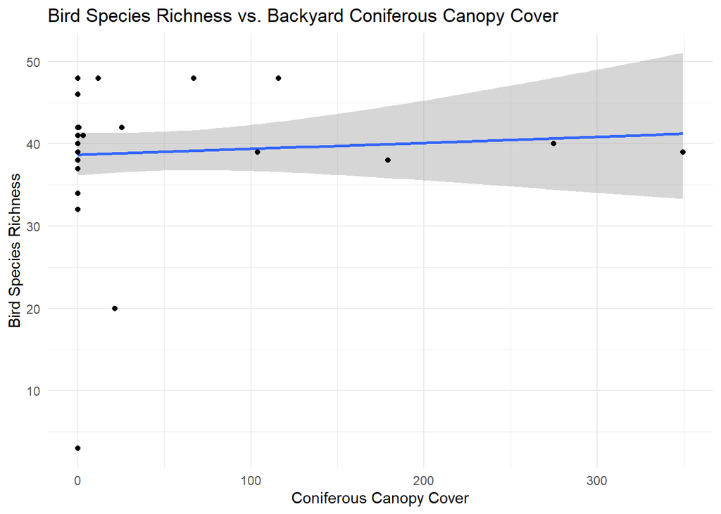

```r
bird_con_canopy_plot <-
  ggplot(no_p21_m13_m11, aes(x = coniferous_canopy,
                          y = bird_diversity)) +
  geom_smooth(method = "glm", method.args = list(family = "poisson")) +
  geom_point() +
  theme_minimal() +
  labs(x = "Coniferous Canopy Cover",
       y = "Bird Species Richness",
       title = "Bird Species Richness vs. Backyard Coniferous Canopy Cover")

bird_con_canopy_plot
```

```r
ggsave(filename = paste0(IMAGE_FILE_PATH, "other-4_bird-vs-coniferous-canopy.png"),
       plot = bird_con_canopy_plot)
```

Example figure caption: Relationship between bird species richness and coniferous canopy cover. The line represents the Poisson model fit with 95% confidence interval (shaded grey).

### Bird Species Richness vs. 50m Canopy Cover

```r
bird_50m_canopy_poisson <-
  glm(bird_diversity ~ canopy_cover_radius_50m,
      family = poisson,
      data = no_p21_m13_m11)
dispersiontest(bird_50m_canopy_poisson)
```

```
##
##  Overdispersion test
##
## data:  bird_50m_canopy_poisson
## z = 0.88315, p-value = 0.1886
## alternative hypothesis: true dispersion is greater than 1
## sample estimates:
## dispersion
##   2.097256
```

p-value = 0.1886 > 0.05, there is no significant overdispersion.

```r
results_bird_50m_canopy_poisson <- tidy(bird_50m_canopy_poisson, exponentiate = TRUE)
results_bird_50m_canopy_poisson
```

```
## # A tibble: 2 × 5
##   term                    estimate std.error statistic p.value
##   <chr>                      <dbl>     <dbl>     <dbl>   <dbl>
## 1 (Intercept)                37.0    0.0586      61.6    0
## 2 canopy_cover_radius_50m     1.00   0.00141      1.09   0.274
```

p-value: 0.2737

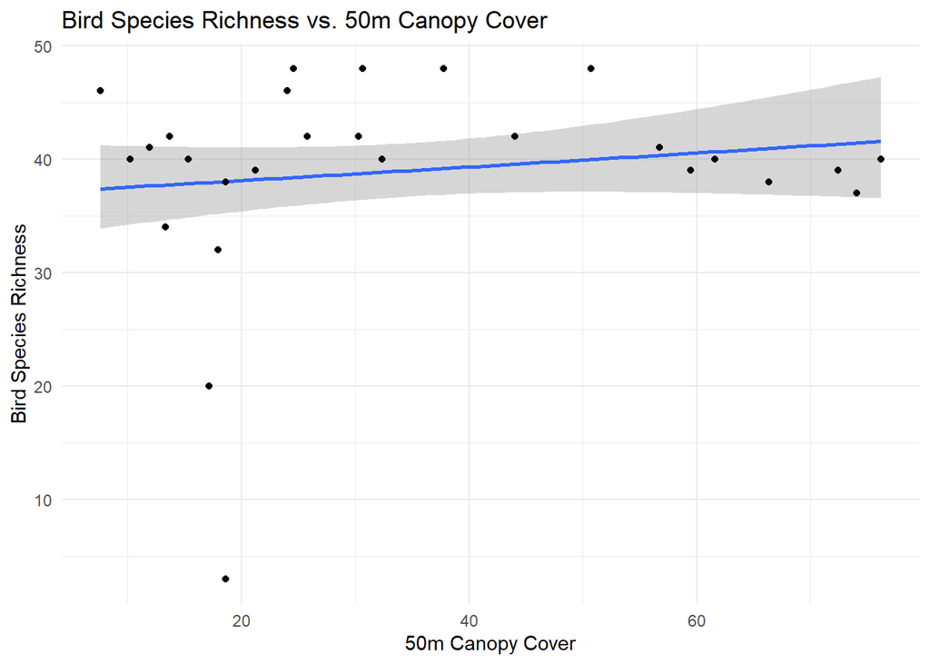

```r
bird_50m_canopy_plot <-
  ggplot(no_p21_m13_m11, aes(x = canopy_cover_radius_50m,
                          y = bird_diversity)) +
  geom_smooth(method = "glm", method.args = list(family = "poisson")) +
  geom_point() +
  theme_minimal() +
  labs(x = "50m Canopy Cover",
       y = "Bird Species Richness",
       title = "Bird Species Richness vs. 50m Canopy Cover")

bird_50m_canopy_plot
```

```r
ggsave(filename = paste0(IMAGE_FILE_PATH, "other-5_bird-vs-50m-canopy.png"),
       plot = bird_50m_canopy_plot)
```

Example figure caption: Relationship between bird species richness and 50m canopy cover. The line represents the Poisson model fit with 95% confidence interval (shaded grey).

### Bird Species Richness vs. 100m Canopy Cover

```r
bird_100m_canopy_poisson <-
  glm(bird_diversity ~ canopy_cover_radius_100m,
      family = poisson,
      data = no_p21_m13_m11)
dispersiontest(bird_100m_canopy_poisson)
```

```
##
##  Overdispersion test
##
## data:  bird_100m_canopy_poisson
## z = 0.90658, p-value = 0.1823
## alternative hypothesis: true dispersion is greater than 1
## sample estimates:
## dispersion
##   2.103016
```

p-value = 0.1823 > 0.05, there is no significant overdispersion.

```r
results_bird_100m_canopy_poisson <- tidy(bird_100m_canopy_poisson, exponentiate = TRUE)
results_bird_100m_canopy_poisson
```

```
## # A tibble: 2 × 5
##   term                     estimate std.error statistic p.value
##   <chr>                       <dbl>     <dbl>     <dbl>   <dbl>
## 1 (Intercept)                 36.7    0.0560      64.3    0
## 2 canopy_cover_radius_100m     1.00   0.00142      1.32   0.187
```

p-value: 0.1872

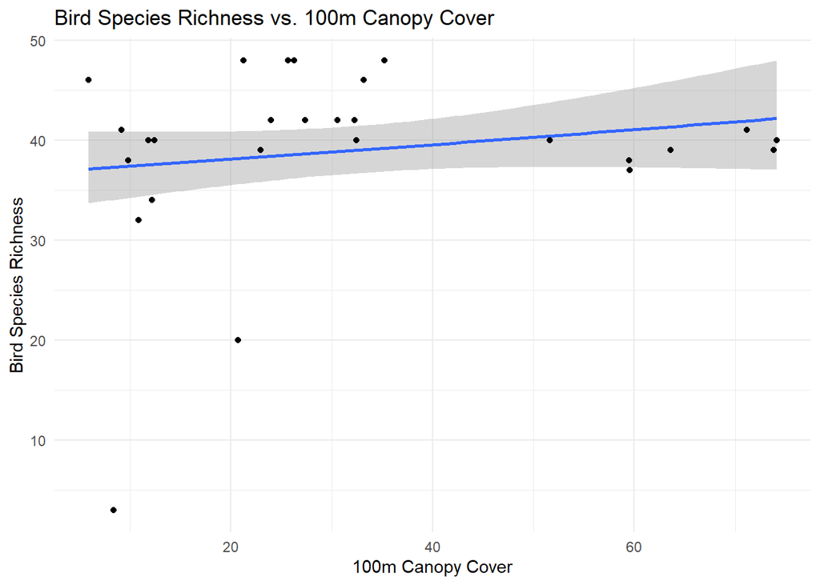

```r
bird_100m_canopy_plot <-
  ggplot(no_p21_m13_m11, aes(x = canopy_cover_radius_100m,
                          y = bird_diversity)) +
  geom_smooth(method = "glm", method.args = list(family = "poisson")) +
  geom_point() +
  theme_minimal() +
  labs(x = "100m Canopy Cover",
       y = "Bird Species Richness",
       title = "Bird Species Richness vs. 100m Canopy Cover")

bird_100m_canopy_plot
```

```r
ggsave(filename = paste0(IMAGE_FILE_PATH, "other-6_bird-vs-100m-canopy.png"),
       plot = bird_100m_canopy_plot)
```

Example figure caption: Relationship between bird species richness and 100m canopy cover. The line represents the Poisson model fit with 95% confidence interval (shaded grey).

### Species of Different Feeding Guilds vs. Canopy Cover

Fitted a Poisson regression model with bird species richness for each feeding guild as the response variable with canopy cover per backyard (percent, 50m, and 100m) as the predictor. Equidispersion was verified using a dispersion test, confirming that Poisson models were appropriate

```r
bird_type_data <- read_excel(BIRD_FILE_PATH, sheet="Birds_info_table") |>
  clean_names() |>
  select(species_code, feeding_guild)

# INSECTIVORE DATA
# get data on which birds are insectivores
insectivore_data <- bird_type_data |>
  filter(feeding_guild == "Insectivore")

# filter bird data to only include insectivores
# count number of insectivores per house
insectivore_house_data <- bird_data |>
  filter(species %in% insectivore_data$species_code) |>
  select(house, species) |>
  unique() |> # remove duplicates
  group_by(house) |>
  summarise(number_insectivores = n())

# add number of insectivores to garden data
garden_data <- left_join(garden_data, insectivore_house_data, by = join_by(house)) |>
  mutate(number_insectivores = replace_na(number_insectivores, 0))


# GRANIVORE DATA
granivore_data <- bird_type_data |>
  filter(feeding_guild == "Granivore")

granivore_house_data <- bird_data |>
  filter(species %in% granivore_data$species_code) |>
  select(house, species) |>
  unique() |> # remove duplicates
  group_by(house) |>
  summarise(number_granivores = n())

garden_data <- left_join(garden_data, granivore_house_data, by = join_by(house)) |>
  mutate(number_granivores = replace_na(number_granivores, 0))


# OMIVORE DATA
omnivore_data <- bird_type_data |>
  filter(feeding_guild == "Omnivore")

omnivore_house_data <- bird_data |>
  filter(species %in% omnivore_data$species_code) |>
  select(house, species) |>
  unique() |> # remove duplicates
  group_by(house) |>
  summarise(number_omnivores = n())

garden_data <- left_join(garden_data, omnivore_house_data, by = join_by(house)) |>
  mutate(number_omnivores = replace_na(number_omnivores, 0))
```

```r
# poisson models and dispersion tests

y_vars_feeding_guild <- c("number_insectivores",
                          "number_granivores",
                          "number_omnivores")

x_vars_canopy <- c("canopy_cover_garden_maybepercentage",
                   "canopy_cover_radius_50m",
                   "canopy_cover_radius_100m")

feeding_models_results <- map_dfr(y_vars_feeding_guild, \(feeding_guild) {

  map_dfr(x_vars_canopy, \(canopy_type) {

    # fit a poisson model for each pairing
    feeding_model <- glm(
      as.formula(paste(feeding_guild, "~", canopy_type)),
      family = poisson,
      data = garden_data
    )

    # dispersion test check
    dispersion_p_value <- dispersiontest(feeding_model)$p.value |>
      round(4)

    # poisson model results (row 2 = the predictor term)
    results <- tidy(feeding_model, exponentiate = TRUE) |>
      slice(2)

    # combine all results into one row
    tibble(
      y_variable = feeding_guild,
      x_variable = canopy_type,
      dispersion_test_p_value = dispersion_p_value
    ) |>
      bind_cols(results)

  })
})

kable(feeding_models_results)
```

| y_variable | x_variable | dispersion_test_p_value | term | estimate | std.error | statistic | p.value |
| --- | --- | --- | --- | --- | --- | --- | --- |
| number_insectivores | canopy_cover_garden_maybepercentage | 0.3945 | canopy_cover_garden_maybepercentage | 1.0010595 | 0.0008382 | 1.2634221 | 0.2064375 |
| number_insectivores | canopy_cover_radius_50m | 0.4221 | canopy_cover_radius_50m | 1.0022158 | 0.0016325 | 1.3558224 | 0.1751557 |
| number_insectivores | canopy_cover_radius_100m | 0.4235 | canopy_cover_radius_100m | 1.0022705 | 0.0016464 | 1.3775105 | 0.1683545 |
| number_granivores | canopy_cover_garden_maybepercentage | 1.0000 | canopy_cover_garden_maybepercentage | 1.0007346 | 0.0011468 | 0.6403388 | 0.5219524 |
| number_granivores | canopy_cover_radius_50m | 1.0000 | canopy_cover_radius_50m | 1.0023057 | 0.0022174 | 1.0386015 | 0.2989901 |
| number_granivores | canopy_cover_radius_100m | 1.0000 | canopy_cover_radius_100m | 1.0023034 | 0.0022372 | 1.0284361 | 0.3037447 |
| number_omnivores | canopy_cover_garden_maybepercentage | 1.0000 | canopy_cover_garden_maybepercentage | 1.0003345 | 0.0023067 | 0.1449945 | 0.8847152 |
| number_omnivores | canopy_cover_radius_50m | 1.0000 | canopy_cover_radius_50m | 1.0000745 | 0.0044673 | 0.0166821 | 0.9866903 |
| number_omnivores | canopy_cover_radius_100m | 1.0000 | canopy_cover_radius_100m | 0.9998022 | 0.0045277 | -0.0436880 | 0.9651531 |

From above, see that equidispersion is verified (dispersion_test_p_value > 0.05).

```r
long_data <- garden_data |>
  select(
    number_insectivores,
    number_granivores,
    number_omnivores,
    canopy_cover_garden_maybepercentage,
    canopy_cover_radius_50m,
    canopy_cover_radius_100m
  ) |>
  pivot_longer(
    cols = starts_with("number_"),
    names_to = "feeding_guild",
    values_to = "richness"
  ) |>
  pivot_longer(
    cols = starts_with("canopy_cover"),
    names_to = "canopy_type",
    values_to = "canopy_cover"
  )

long_data <- long_data |>
  mutate(
    valid_pair = case_when(
      feeding_guild == "number_insectivores" &
        canopy_type %in% c("canopy_cover_garden_maybepercentage",
                           "canopy_cover_radius_50m",
                           "canopy_cover_radius_100m") ~ TRUE,
      feeding_guild == "number_granivores" &
        canopy_type %in% c("canopy_cover_garden_maybepercentage",
                           "canopy_cover_radius_50m",
                           "canopy_cover_radius_100m") ~ TRUE,
      feeding_guild == "number_omnivores" &
        canopy_type %in% c("canopy_cover_garden_maybepercentage",
                           "canopy_cover_radius_50m",
                           "canopy_cover_radius_100m") ~ TRUE,
      TRUE ~ FALSE
    )
  ) |>
  filter(valid_pair)

feeding_labels <- c(
  number_insectivores = "Insectivore",
  number_granivores = "Granivore",
  number_omnivores = "Omnivore"
)

canopy_labels <- c(
  canopy_cover_garden_maybepercentage = "Backyard",
  canopy_cover_radius_50m = "50m",
  canopy_cover_radius_100m = "100m"
)

plot_data <- long_data |>
  mutate(
    feeding_label = feeding_labels[feeding_guild],
    canopy_label = canopy_labels[canopy_type]
  ) |>
  mutate(
    canopy_label = factor(
      canopy_label,
      levels = c("Backyard", "50m", "100m")
    ),
    feeding_label = factor(
      feeding_label,
      levels = c("Insectivore", "Granivore", "Omnivore")
    )
  )

feeding_models_results <- feeding_models_results |>
 rename(model_p_value = p.value)

p_labels <- feeding_models_results |>
  mutate(
    feeding_label = feeding_labels[y_variable],
    canopy_label = canopy_labels[x_variable],
    label = paste0("p = ", signif(model_p_value, 3))
  ) |>
  select(feeding_label, canopy_label, label)

annot_data <- p_labels |>
  mutate(
    canopy_label = factor(canopy_label, levels = c("Backyard", "50m", "100m")),
    feeding_label = factor(feeding_label, levels = c("Insectivore", "Granivore", "Omnivore")),
    canopy_cover = -Inf,
    richness = Inf
  )
```

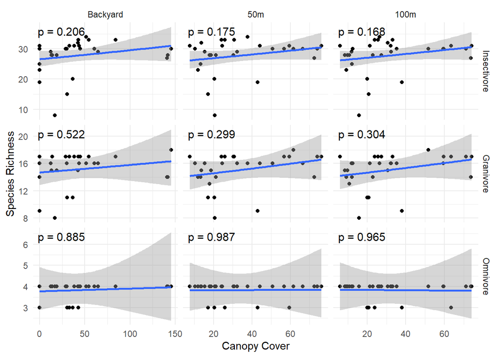

```r
feeding_guild_canopy_plot <-
  ggplot(plot_data, aes(x = canopy_cover, y = richness)) +

  geom_point() +

  geom_smooth(
    method = "glm",
    method.args = list(family = poisson),
    se = TRUE
  ) +

  geom_text(
    data = annot_data,
    aes(x = canopy_cover, y = richness, label = label),
    inherit.aes = FALSE,
    hjust = -0.1,
    vjust = 1.5,
    size = 4
  ) +

  facet_grid(
    feeding_label ~ canopy_label,
    scales = "free"
  ) +

  theme_minimal() +

  labs(
    x = "Canopy Cover",
    y = "Species Richness"
  )

feeding_guild_canopy_plot
```

```r
ggsave(filename = paste0(IMAGE_FILE_PATH, "other-7_feeding_guilds-vs-canopy.png"),
       plot = feeding_guild_canopy_plot)
```

Example figure caption: Relationship between granivore, insectivore, and omnivore bird species richness and backyard canopy cover (%), 50m canopy cover, and 100m canopy cover. The lines represents the Poisson model fit with 95% confidence interval (shaded grey).

### Bird Species Richness vs. Total Native Tree Canopy Cover

```r
bird_total_native_canopy_poisson <-
  glm(bird_diversity ~ native_canopy,
      family = poisson,
      data = garden_data)
dispersiontest(bird_total_native_canopy_poisson)
```

```
##
##  Overdispersion test
##
## data:  bird_total_native_canopy_poisson
## z = 1.2013, p-value = 0.1148
## alternative hypothesis: true dispersion is greater than 1
## sample estimates:
## dispersion
##   2.327545
```

p-value = 0.1148 > 0.05, there is no significant overdispersion.

```r
results_bird_total_native_canopy_poisson <- tidy(bird_total_native_canopy_poisson, exponentiate = TRUE)
results_bird_total_native_canopy_poisson
```

```
## # A tibble: 2 × 5
##   term          estimate std.error statistic p.value
##   <chr>            <dbl>     <dbl>     <dbl>   <dbl>
## 1 (Intercept)      37.3   0.0320      113.     0
## 2 native_canopy     1.00  0.000391      1.07   0.284
```

p-value: 0.2838

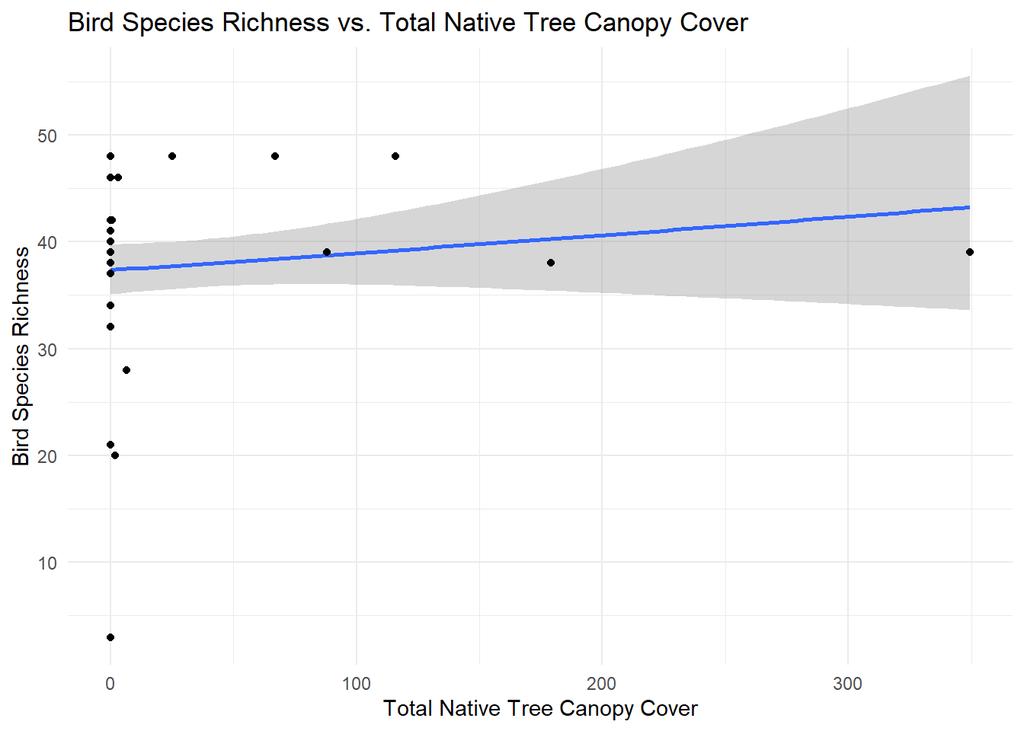

```r
bird_bird_total_native_canopy_plot <-
  ggplot(garden_data, aes(x = native_canopy,
                          y = bird_diversity)) +
  geom_smooth(method = "glm", method.args = list(family = "poisson")) +
  geom_point() +
  theme_minimal() +
  labs(x = "Total Native Tree Canopy Cover",
       y = "Bird Species Richness",
       title = "Bird Species Richness vs. Total Native Tree Canopy Cover")

bird_bird_total_native_canopy_plot
```

```r
ggsave(filename = paste0(IMAGE_FILE_PATH, "other-8_bird-vs-total-native-canopy.png"),
       plot = bird_bird_total_native_canopy_plot)
```

Example figure caption: Relationship between bird species richness and total native tree canopy cover. The line represents the Poisson model fit with 95% confidence interval (shaded grey).

### Bird Species Richness vs. Proportion of Native Tree Canopy Cover

divide by total tree canopy cover

```r
bird_prop_native_canopy_poisson <-
  glm(bird_diversity ~ native_canopy_prop,
      family = poisson,
      data = garden_data)
dispersiontest(bird_prop_native_canopy_poisson)
```

```
##
##  Overdispersion test
##
## data:  bird_prop_native_canopy_poisson
## z = 1.1305, p-value = 0.1291
## alternative hypothesis: true dispersion is greater than 1
## sample estimates:
## dispersion
##   2.214712
```

p-value = 0.1291 > 0.05, there is no significant overdispersion.

```r
results_bird_prop_native_canopy_poisson <- tidy(bird_prop_native_canopy_poisson, exponentiate = TRUE)
results_bird_prop_native_canopy_poisson
```

```
## # A tibble: 2 × 5
##   term               estimate std.error statistic p.value
##   <chr>                 <dbl>     <dbl>     <dbl>   <dbl>
## 1 (Intercept)           36.5     0.0336    107.    0
## 2 native_canopy_prop     1.23    0.0899      2.33  0.0195
```

p-value: 0.01955

This is significant, but the following graph does not inspire confidence.

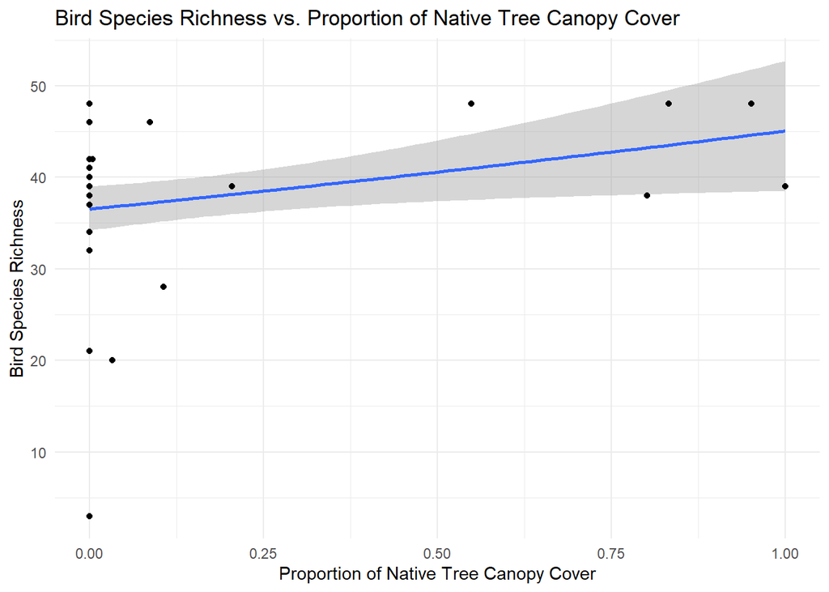

```r
bird_bird_prop_native_canopy_plot <-
  ggplot(garden_data, aes(x = native_canopy_prop,
                          y = bird_diversity)) +
  geom_smooth(method = "glm", method.args = list(family = "poisson")) +
  geom_point() +
  theme_minimal() +
  labs(x = "Proportion of Native Tree Canopy Cover",
       y = "Bird Species Richness",
       title = "Bird Species Richness vs. Proportion of Native Tree Canopy Cover")

bird_bird_prop_native_canopy_plot
```

```r
ggsave(filename = paste0(IMAGE_FILE_PATH, "other-9_bird-vs-proportion-native-canopy.png"),
       plot = bird_bird_prop_native_canopy_plot)
```

Example figure caption: Relationship between bird species richness and proportion of native tree canopy cover. The line represents the Poisson model fit with 95% confidence interval (shaded grey).